# Rafael Nadal vs Novak Djokovic

Settembre 2023

## L’incontro

Il **59°** incontro tra i due, che vede Djokovic in vantaggio per 30 a 28, durerà più di 4 ore, vedendo vincente lo spagnolo con il punteggio di **6-2, 4-6, 6-2, 7-6(4)**. Considerati i dolori al piede e le condizioni atmosferiche con umidità e freddo sfavorevoli al suo gioco carico di rotazioni, la vittoria di Nadal contro un Djokovic in grande forma è ancora più spettacolare.

- Come ha fatto Nadal a vincere questa partita?
- Quali sono state le strategie vincenti?
- Cosa ha sbagliato Djokovic?

### **Il dataset**

I dati sono stati registrati [manualmente](https://fcpythonvideocoder.netlify.app/) e includono informazioni sulla posizione della pallina e dei giocatori, sul tipo di colpo, velocità della palla e punteggio. Crediti: [Gerald Lim](https://glad94.github.io/)

## Serve bounce position

**First** and **second** serve placement density map

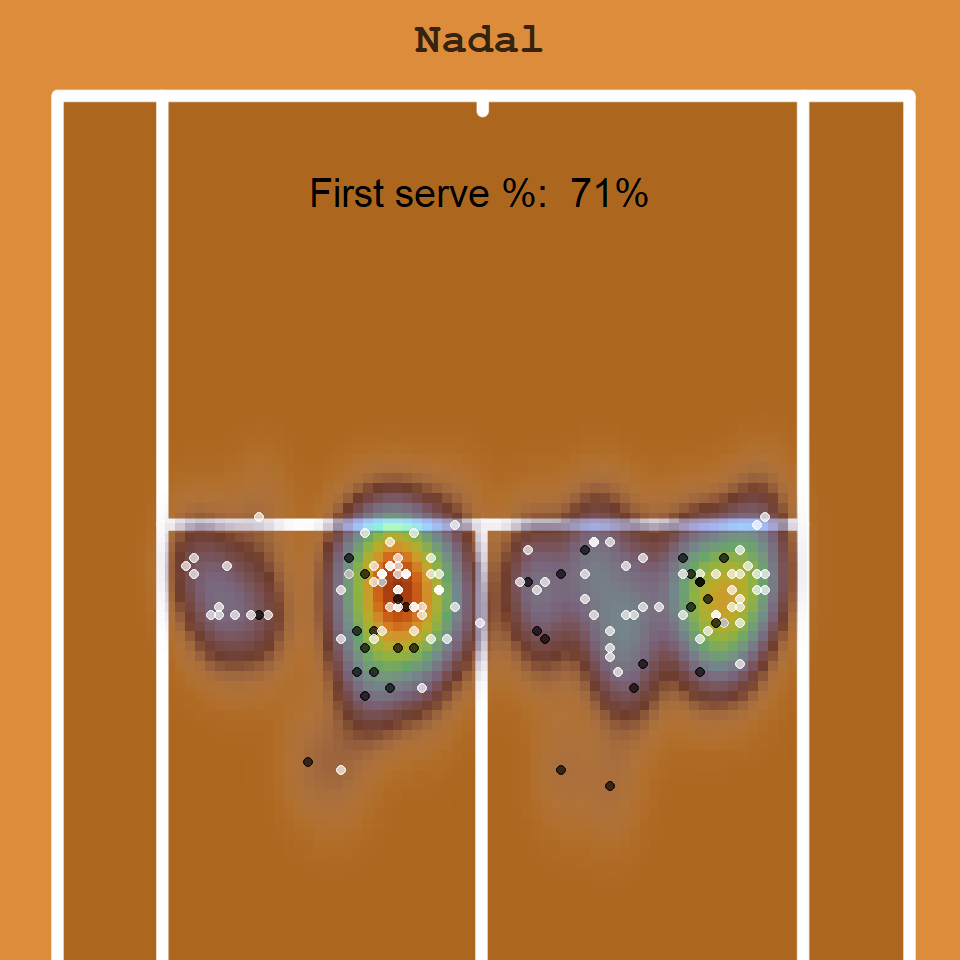

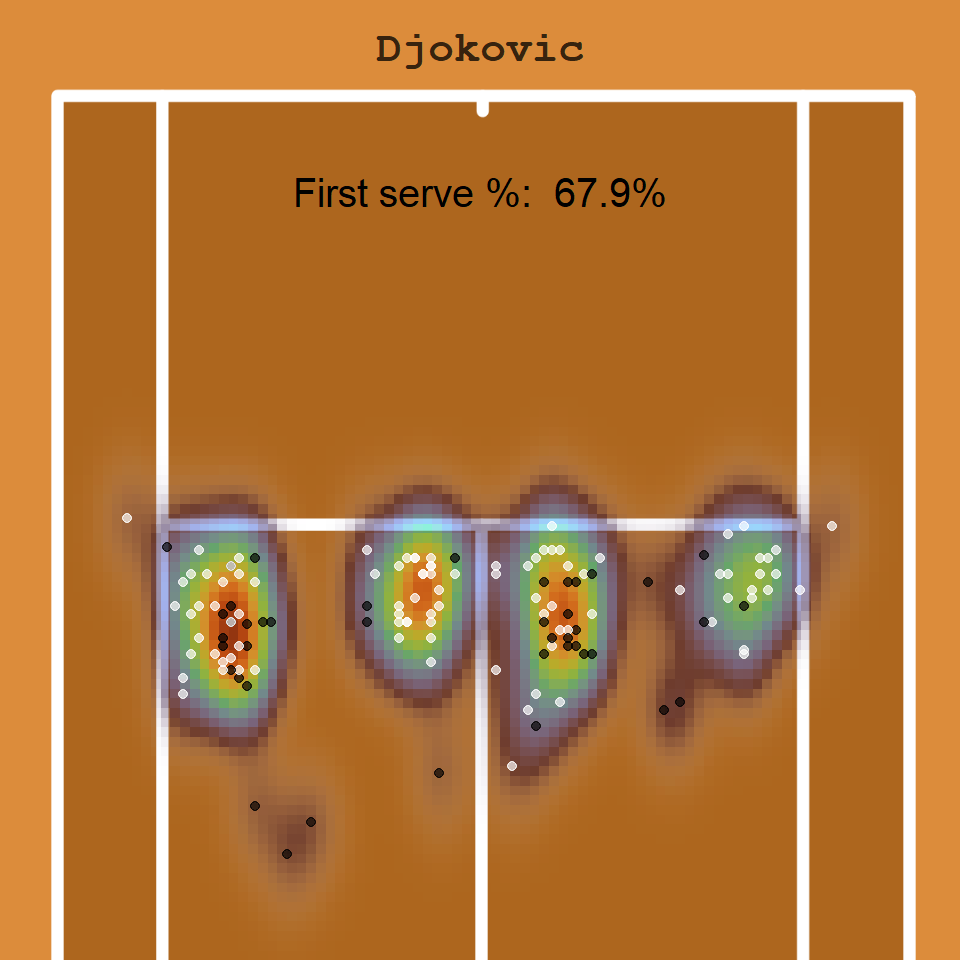

## First and second serve speeds

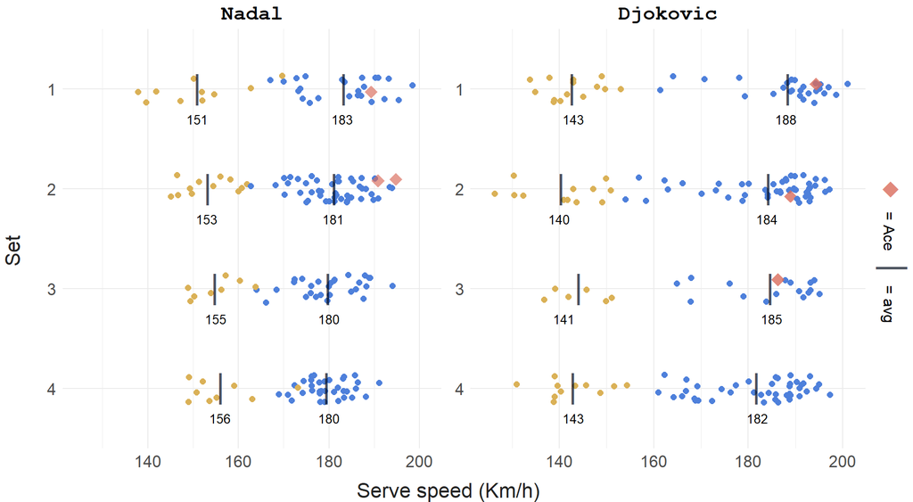

## Strike point density map

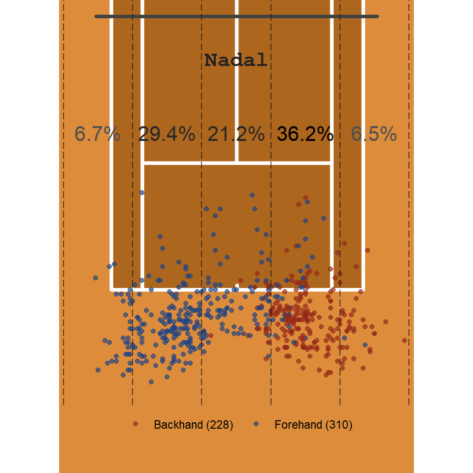

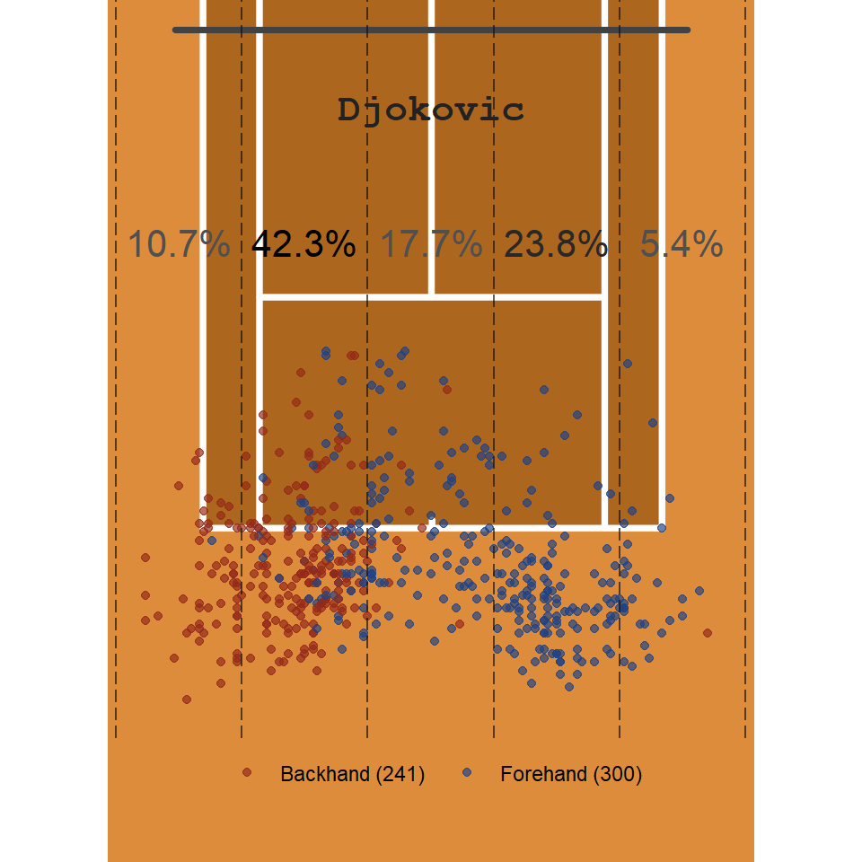

## Djokovic backhand groundstrokes

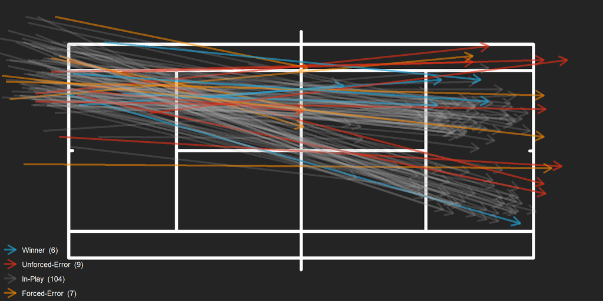

## Nadal backhand groundstrokes

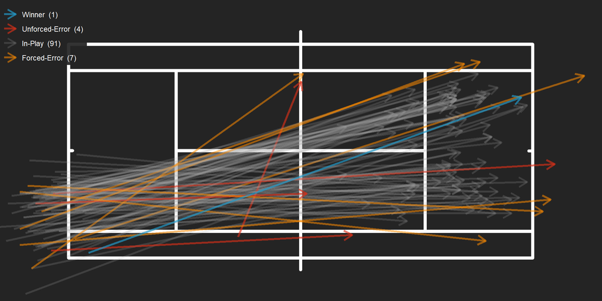

## Djokovic forehand groundstrokes

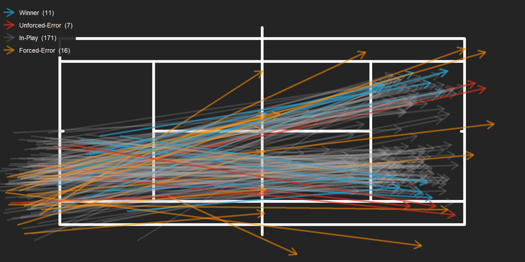

## Nadal inside in & out forehand groundstrokes

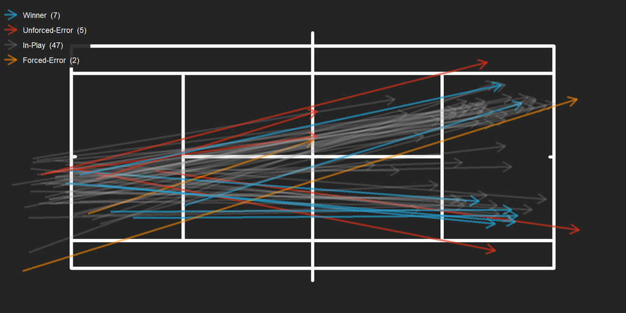

## Nadal inside in forehand groundstrokes

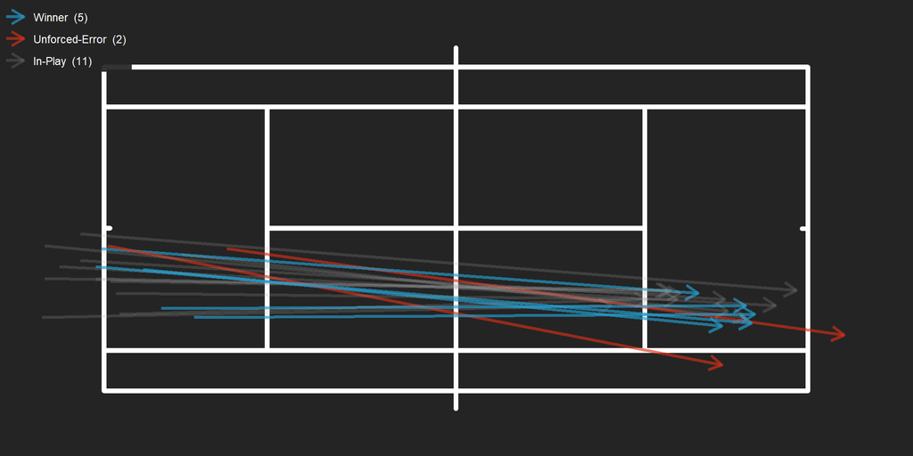

## Djokovic is out of touch: drop-shot

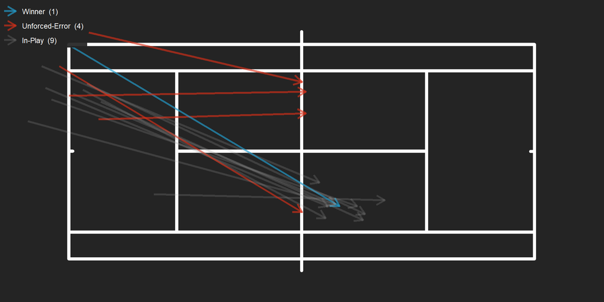

## Djokovic is out of touch: slice

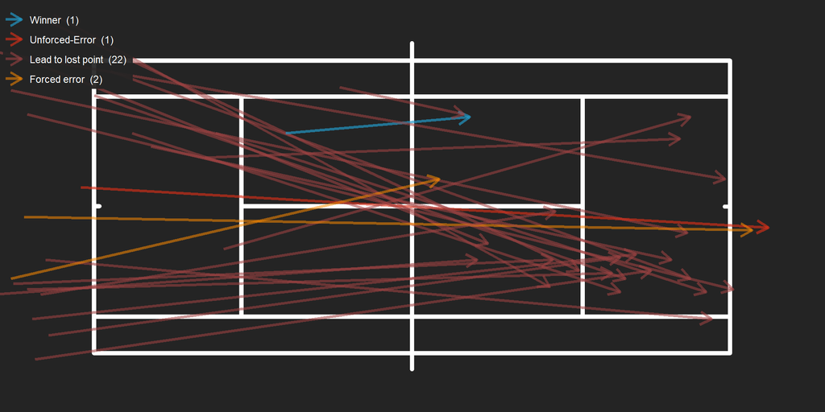

## Under pressure

Set points, Break points, Deuce points

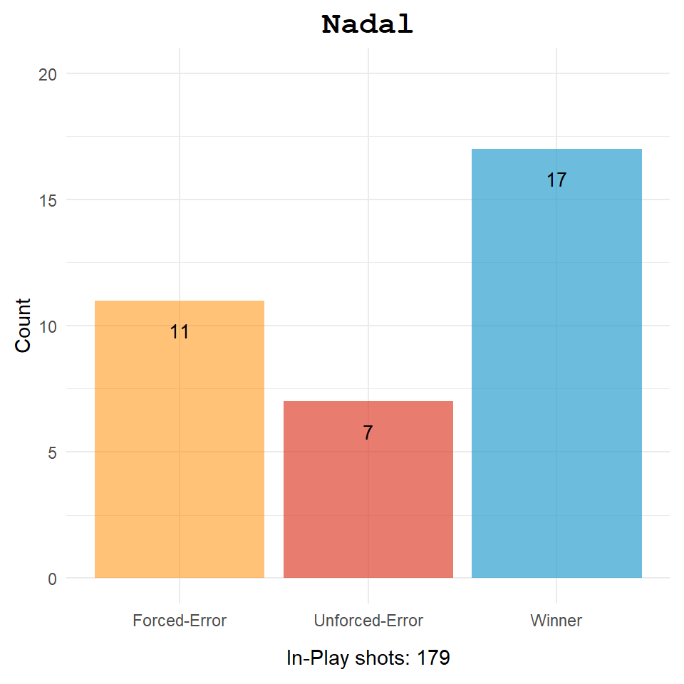

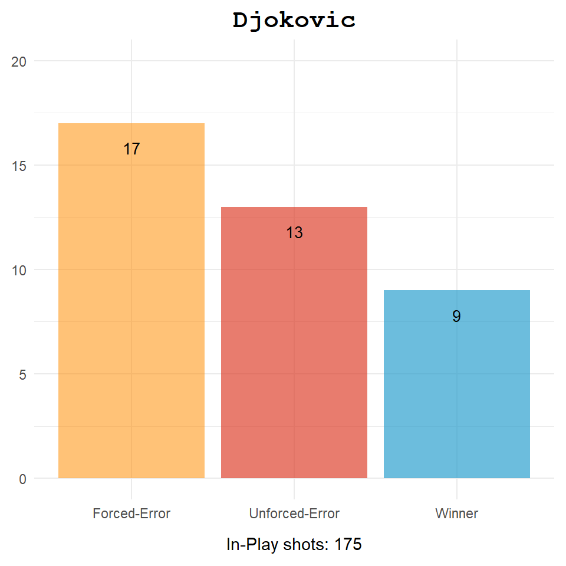

## Points

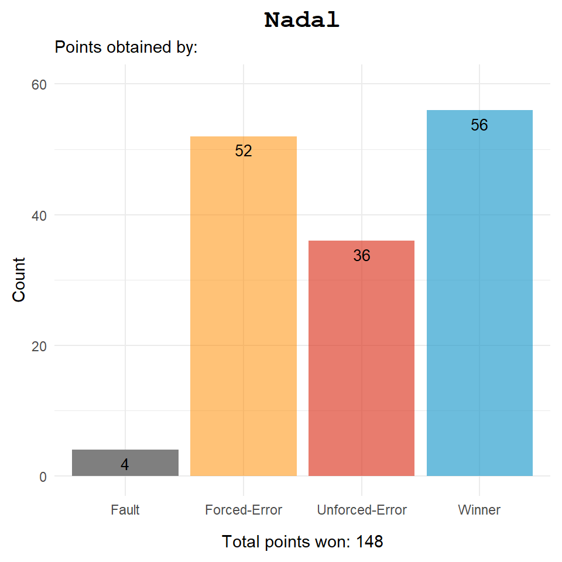

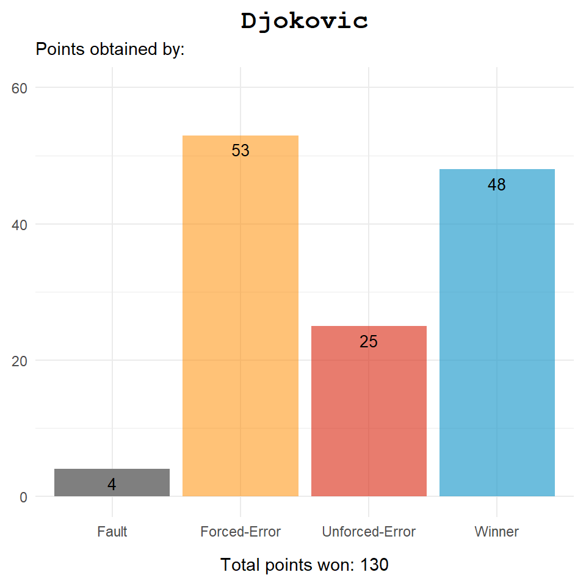

## Conclusioni

Nadal è riuscito a vincere mantenendo un livello altissimo durante tutta la partita, concedendo appena 25 errori non forzati su un totale di quasi 900 colpi giocati. Ha saputo sfruttare le “debolezze” di Djokovic e annullare i suoi tentativi di attacco. Tutto questo con un piede dolorante, che qualche settimana prima l’aveva portato a temere per la fine della sua carriera. In semifinale batterà Zverev e in finale Ruud, senza perdere un set, conquistando il suo **quattordicesimo** Roland Garros.